# DATA612_Discussion1

Samriti Malhotra

June 10, 2019

# Pinterest Recommender System

Pinterest is a social network that allows users to visually share, and discover new interests by posting (known as ‘pinning’ on Pinterest) images or videos to their own or others’ boards (i.e. a collection of ‘pins,’ usually with a common theme) and browsing what other users have pinned.

As with most other social networks, users can perform standard social networking functions such as following the boards of their friends, liking and commenting on other users’ pins, re-pinning content to their own boards, sharing others’ pins on Facebook and Twitter or via email, and even embedding individual pins on their website or blog.Pinterest saw incredible growth in 2013 - for the first time ever, Pinterest surpassed email as a sharing medium, and even outpaced Facebook.

# Data Model

In the Pinterest data model, each pin is an instance of an image (uniquely identified by an image signature) with a link and description. Although each pin is on a single board, the same image can be used in many pins across different boards:when a pin is saved to a new board, a copy of the pin is created. Pin information is typically aggregated on the image signature level, providing richer metadata than individual pin instances. For convenience, future references to “querypin” and “result pin” actually refer to the aggregation of pins with the same image signature.

The Related Pins system comprises three major components summarized below.

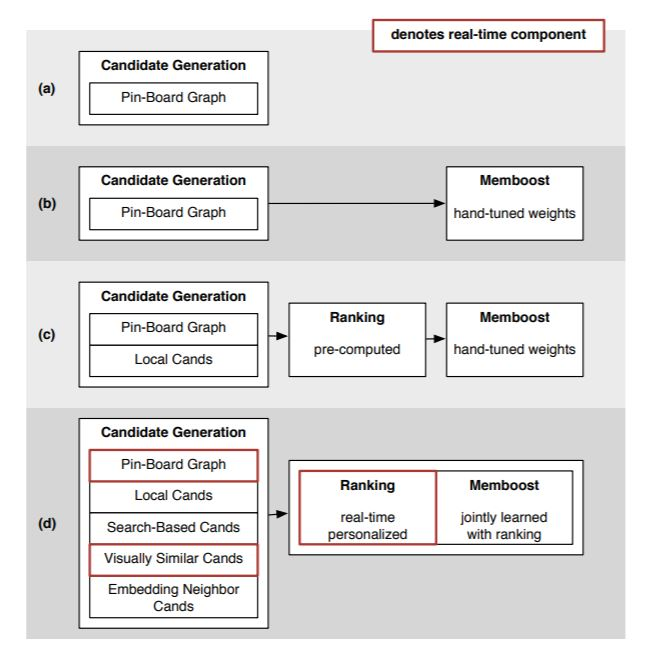

**Candidate generation.** Narrow the candidate set—the set of pins eligible for Related Pin recommendations—from billions to roughly 1,000 pins that are likely related to the query pin.

**Memboost.** A portion of system memorizes past engagement on specific query and result pairs . It describes how the account is positioned using historical data.

For building ranking system training data collection method, learning objective, and model type are used.  
Training Data Collection

- Memboost scores as training data. Conceptually, the ranker can learn to predict Memboost scores for query-result pairs without enough log data to have a confident Memboost estimate.
- Individual Related Pins sessions. A session is defined as a single user’s interactions with Related Pins results from a single query pin. We can sample these interactions directly as training data.

Model Objective learning to rank approaches are broadly categorized into pointwise, pairwise, and listwise approaches. The main difference between these approaches is whether the loss function considers one, two, or many candidates at a time.

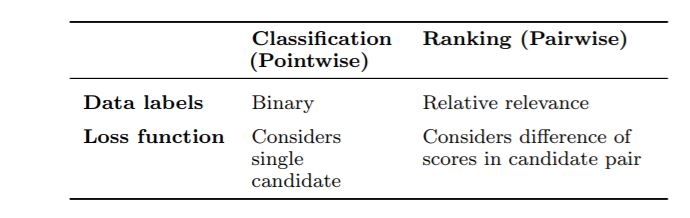

Below Table shows the various combinations of training data, objective, and model that are explored in Related Pins ranking.

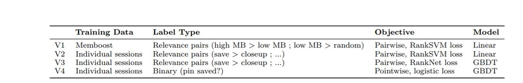

### Possible Approach

Recommender systems literature showcase many impressive state-of-the-art systems. It was important to diversify content, because engagement is not always correlated to relevance. Finally, making more of the system real-time, both in candidate generation and ranking, significantly increased velocity of experimentation and improved responsiveness of the results.

### Sources

*Building the Next New York Times Recommendation Engine - NY Times* _https://open.blogs.nytimes.com/2015/08/11/building-the-next-new-york-times-recommendation-engine/_

*Pinterest Website Reviews* _https://www.infront.com/blog/the-blog/what-is-pinterest-and-how-does-it-work_

*Recommender system* _https://www.infoworld.com/article/3241852/how-to-implement-a-recommender-system.html_

*https://arxiv.org/pdf/1702.07969.pdf*